# Primary production in ice cores

Philippe Massicotte

2020-06-23

## Context

Calculate primary production in ice at station 19. Since there was no PvsE curve measured at this station, parameters from station 32 will be used.

## PAR data

First, we have to calculate PAR just bellow the surface. We will use the pyranometer data to estimate PAR under the ice based on transmittance measured by both the ROV and the SUIT.

### Pyranometer

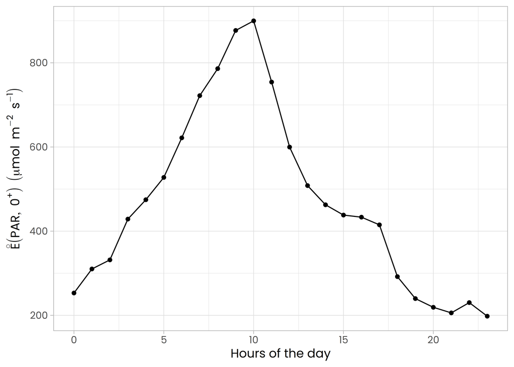

### Transmittance

Measured by the ROV and the SUIT. Note the large differences between the two methods (see our paper for more information).

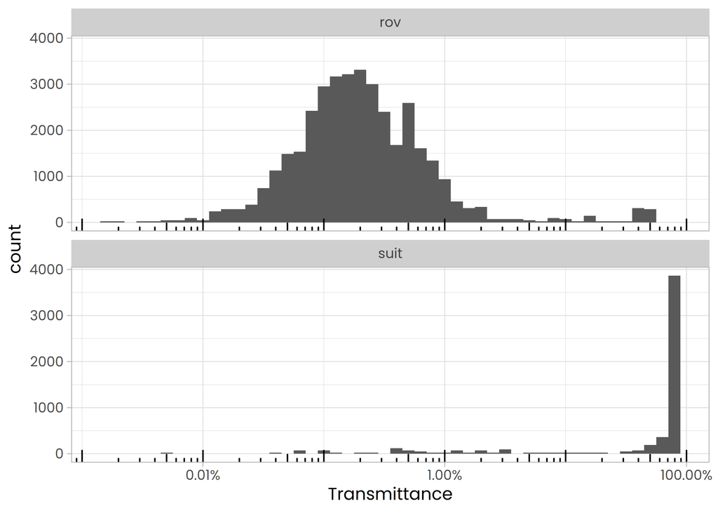

PAR just under the ice was estimated using PAR measured from the pyranometer and transmittance measured from the ROV and the SUIT. At station 19, there was a total of 1561 and 231 transmittance measurements from the ROV and the SUIT. Hence, there are the same numbers of PAR estimations.

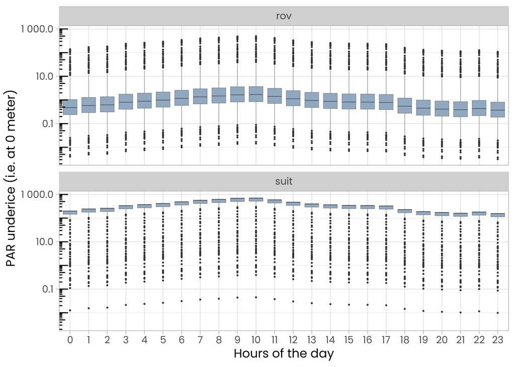

## PvsE parameters

Use parameters from station 32 sampled on 2015-06-07.

| date | depth | ps | alpha |
| --- | --- | --- | --- |
| 2015-06-07 | Ice-1 | 2.085817 | 0.0301104 |
| 2015-06-07 | Ice-2 | 2.121496 | 0.0340496 |

## Calculate Primary production

This is the formula used to calculate primary production:

$$pp = ps * (1 - exp(-\text{alpha} * \text{PAR} / ps))$$

The following graphic shows the averaged hourly primary production based on transmittance measured by both the ROV and the SUIT.

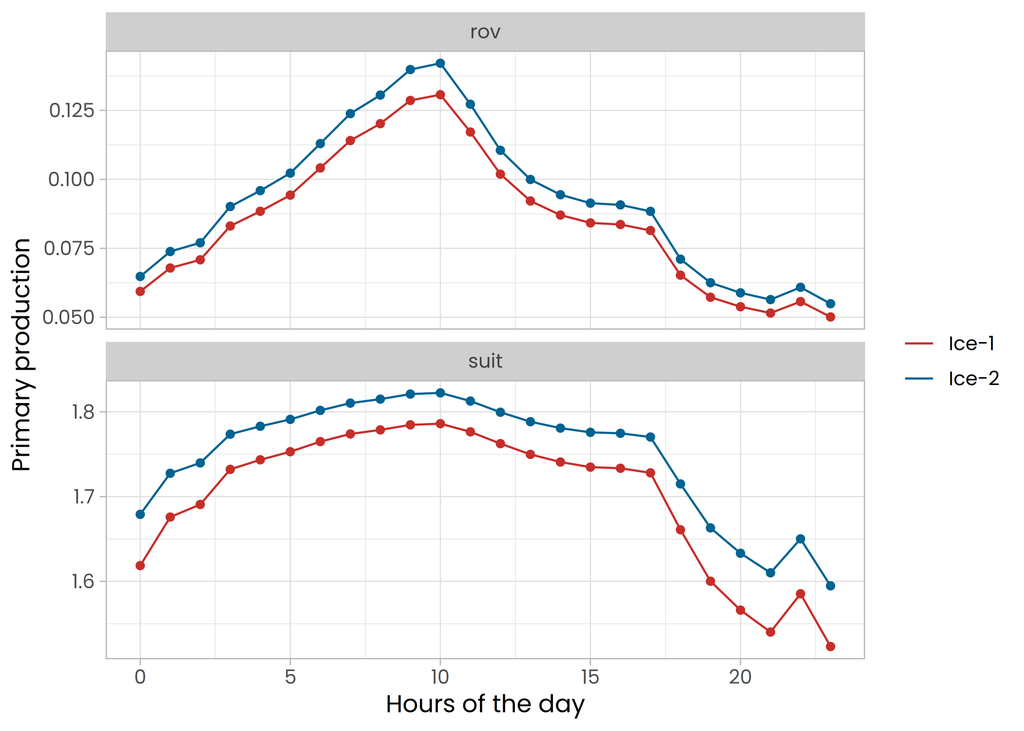

### Daily primary production

Daily primary production can be calculated by integrating hourly primary production (i.e. the areas under each curve in the previous graphic).

| transmittance_source | depth | daily_pp |
| --- | --- | --- |
| rov | Ice-1 | 1.988100 |
| rov | Ice-2 | 2.160655 |
| suit | Ice-1 | 39.232556 |
| suit | Ice-2 | 40.295953 |